# Reproducible Research: Course Project 1

William Chen

December 11, 2016

## 1. Reading in the dataset “Activity monitoring data”

use read.csv to read the csv file activity.csv to create mydata

```r
mydata <- read.csv("activity.csv")
```

## 2. Histogram the steps

sum mydata to get steps per day to mydata1 then histogram the steps by day

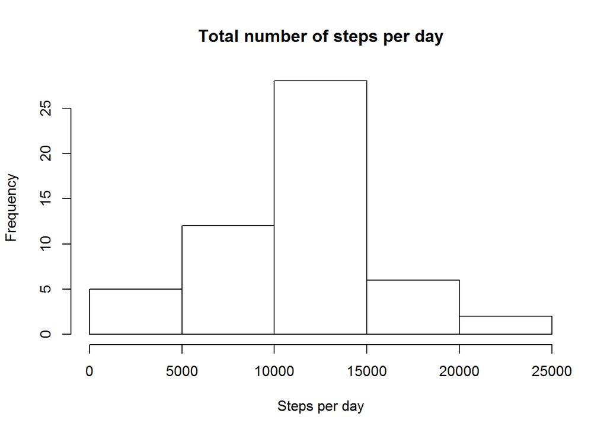

```r
mydata1<-aggregate(steps~date,data=mydata, sum,na.rm=TRUE)
hist(mydata1$steps,main = "Total number of steps per day", xlab = "Steps per day")
```

## 3. Mean/median of the steps

use mean and median function to get the mean/median of the steps

```r
mean(mydata1$steps);median(mydata1$steps)
```

```
## [1] 10766.19
```

```
## [1] 10765
```

## 4.What is the average daily activity pattern?

aggregate mydata by mean of the interval to mydata2, plot mydata2

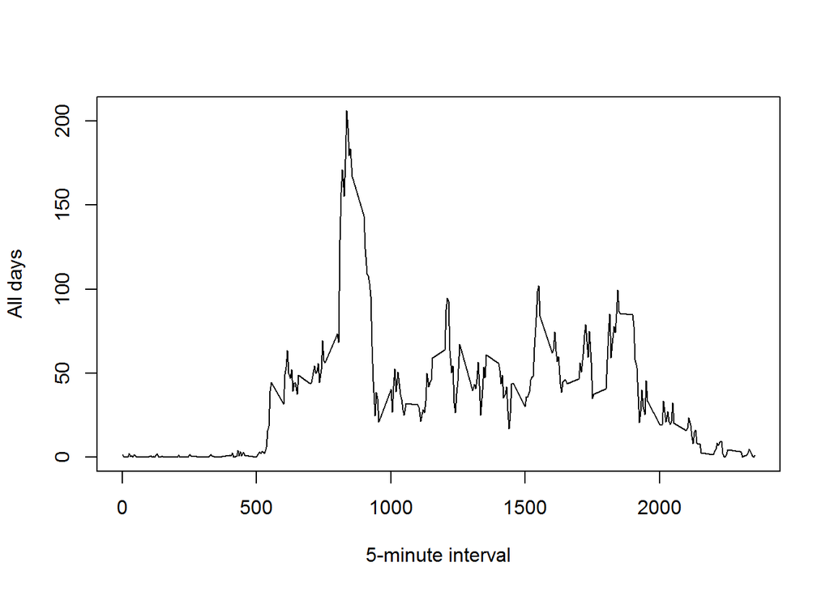

```r
mydata2<-aggregate(steps~interval,data=mydata, mean,na.rm=TRUE)
plot(mydata2,type = "l",xlab="5-minute interval", ylab="All days")
```

## 5.Which 5-minute interval, on average across all the days in the dataset, contains the maximum number of steps?

get the max position from mydata2 and add to the plot

```r
mydata2[which.max(mydata2$steps),1]
```

```
## [1] 835
```

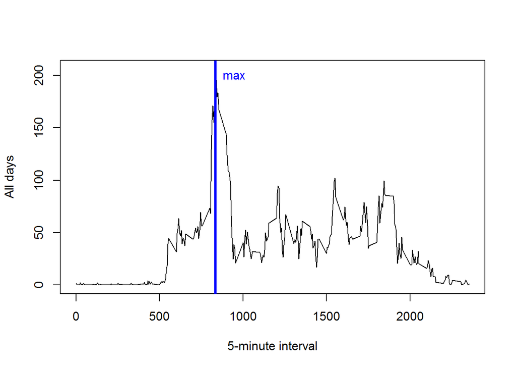

```r
#mydata2<-aggregate(steps~interval,data=mydata, mean,na.rm=TRUE)
plot(mydata2,type = "l",xlab="5-minute interval", ylab="All days")
abline(v = mydata2[which.max(mydata2$steps),1], col="blue", lwd=3, lty=1)
text(mydata2[which.max(mydata2$steps),1],200,labels="max", pos=4, col="blue")
```

## 6.Code to describe and show a strategy for imputing missing data

create mydat3 from mydata find all the NA assign all the NA to mean get mean/median

```r
mydata3 <- mydata
mydatana<-is.na(mydata3$steps)
sum(mydatana)
```

```
## [1] 2304
```

```r
mydata3$steps[mydatana]<-mean(mydata3$steps, na.rm = TRUE)
mydata4<-aggregate(steps~date,data=mydata3, sum,na.rm=TRUE)
mean(mydata4$steps);median(mydata4$steps)
```

```
## [1] 10766.19
```

```
## [1] 10766.19
```

## 7.Histogram of the total number of steps taken each day after missing values are imputed

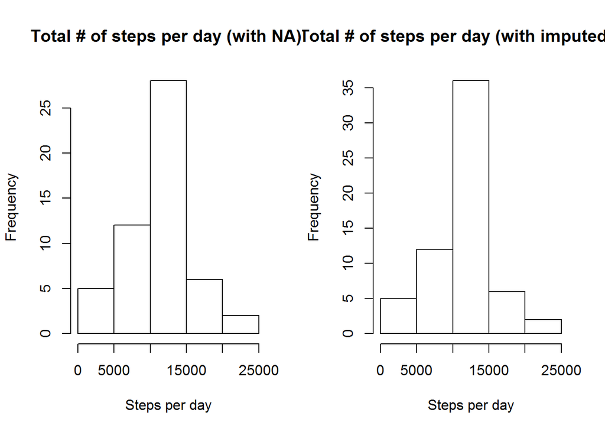

```r
par(mfcol = c(1, 2))
hist(mydata1$steps,main = "Total # of steps per day (with NA) ", xlab = "Steps per day")
hist(mydata4$steps,main = "Total # of steps per day (with imputed NA)", xlab = "Steps per day")
```

## 8.Panel plot comparing the average number of steps taken per 5-minute interval across weekdays and weekends

subet those days in weekdays to mydata5weekday, weekend to mydata5weekend aggregate mydata5weekday and mydata5weekend for the mean plot mydata5weekday1 and mydata5weekend1

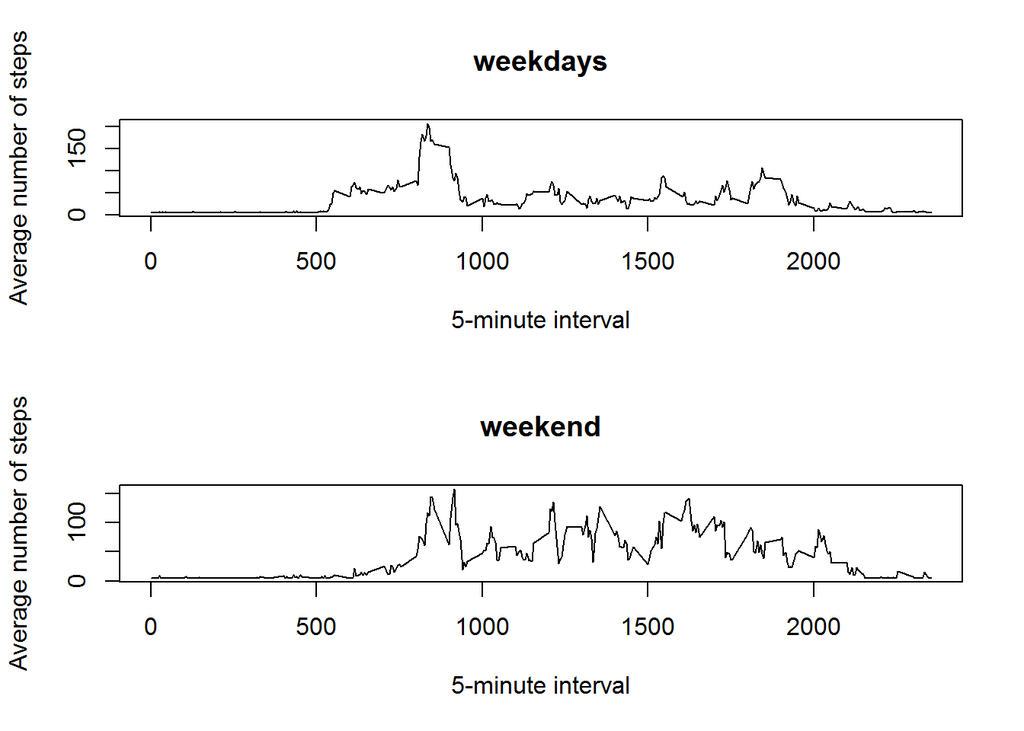

```r
mydata5weekday <- subset(mydata3, weekdays(as.Date(mydata3$date)) %in% c("Monday", "Tuesday", "Wednesday", "Thursday", "Friday"))
mydata5weekend <- subset(mydata3, weekdays(as.Date(mydata3$date)) %in% c("Saturday","Sunday"))
mydata5weekday1<-aggregate(steps~interval,data=mydata5weekday, mean,na.rm=TRUE)
mydata5weekend1<-aggregate(steps~interval,data=mydata5weekend, mean,na.rm=TRUE)
par(mfcol = c(2, 1))
plot(mydata5weekday1,type = "l",xlab="5-minute interval", ylab="Average number of steps", main="weekdays")
plot(mydata5weekend1,type = "l",xlab="5-minute interval", ylab="Average number of steps",main="weekend")
```

this is the end of the file.